# Group 2: Project Part 3

## 1. Setup

```r
setwd("/Users/anjali/Documents/university/Econ_5305/project/Group2_Final/")
rm(list = ls())
```

```r
library(openxlsx)
library(readxl)
library(ggplot2)
library(dynlm)
library(tidyverse)
library(forecast)
library(urca)
library(lubridate)
library(TSstudio)
```

```r
data_1 <- read_excel("./delivery_data.xlsx")
#View(data_1)

# read the time series for unemployment
# converting the counts to in 1000 values for easier analysis
DELIVERIES<-ts(data_1$count/100000,frequency=365, start = c(2020,1,2))
```

## 2. Preliminary Exploratory Data Analysis

### 2.1 5 Number Summary and Time Series Plot

```r
cat("Delivery Data")
```

```
Delivery Data
```

```r
summary(DELIVERIES)
```

```
   Min. 1st Qu.  Median    Mean 3rd Qu.    Max.
0.00005 2.56658 2.85627 2.88577 3.26702 5.35246
```

```r
cat("Count of the data")
```

```
Count of the data
```

```r
length(DELIVERIES)
```

```
[1] 1216
```

```r
cat("Standard deviation: ", sd(DELIVERIES))
```

```
Standard deviation:  0.6793256
```

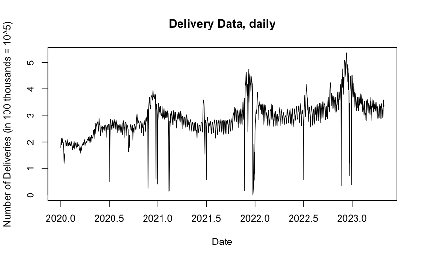

```r
plot.ts(DELIVERIES, main="Delivery Data, daily",xlab = "Date",ylab ="Number of Deliveries (in 100 thousands = 10^5)")
```

**Plot Interpretation:** The time series shows a slight upward trend over the time period from Jan 2020 to March 2023. We also see clear seasonality for each year which corresponds to people tending to buy more products towards the end of the year during the holidays. There is also possibility of there being weekly (7 day) cyclical behavior as well that we can could possibly explore. All the data expect for Jan 2020 and Feb 2020 are affected by COVID-19 buying behavior. We can see the rapid rise in online purchasing from 2020 March onwards till about 6 months.

## 2.2 Stationarity Checks

```r
ur.df(DELIVERIES,type="trend",lags=0)
```

```
###############################################################
# Augmented Dickey-Fuller Test Unit Root / Cointegration Test #
###############################################################

The value of the test statistic is: -16.3575 89.1955 133.7872
```

```r
ur.df(DELIVERIES,type="drift",lags=0)
```

```
###############################################################
# Augmented Dickey-Fuller Test Unit Root / Cointegration Test #
###############################################################

The value of the test statistic is: -12.582 79.1587
```

**Testing for Unit Root:** The test statistic is very low and therefore we can conclude that there is no unit root. Therefore we continue to look at the ACF and PACF of the time series without taking difference. We can try models with first differnce as well to see if they perform better.

#### 2.3 Auto-Correlations

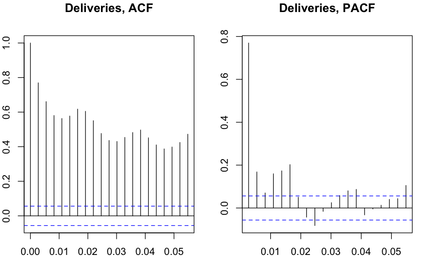

```r
par(mfrow=c(1,2), mar = c(3, 2, 3, 2))
acf(DELIVERIES,lag= 20, main = "Deliveries, ACF")
pacf(DELIVERIES,lag= 20, main ="Deliveries, PACF")
```

**Key Findings:** - In the ACF we see that that the correlation continuously falls but that it has some bumps. These bumps are approximately around 7 lags which indicates a weekly cyclical pattern. - Given that the there is a continuous fall in autocorrelation we can try to use AR(1) and similar models - Looking at PACF we see the a a large spike a lag1 . Then spikes at lag = 2,4,5,6. We can try AR(1) , AR(2), AR(6) - Since there are recurring small spikes we can also try ARMA(1,1), ARMA(2,2), ARMA(6,1), ARMA(6,2) , ARMA (6,6) - We do not see a smooth decay of towards zero in the PACF hence MA model is not indicated. Nevertheless we plan on modeling MA(1) and MA(2) process to see output patterns. - Seasonality - Annual and Weekly also needs to be considered.

#### 2.4 Decompostion Analysis

```r
decomposed <- decompose(DELIVERIES, type = "multiplicative")
seasonal <- decomposed$seasonal
trend <- decomposed$trend
random <- decomposed$random

par(mfrow=c(2,2) , mar = c(3, 2, 3, 2))
plot(DELIVERIES, main = "Original Time Series")
plot(trend, main = "Trend Component")
```

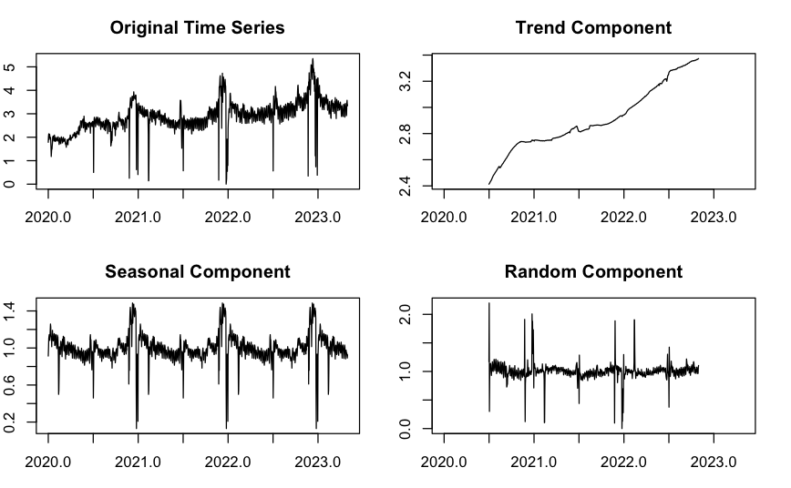

```r
plot(seasonal, main = "Seasonal Component")
plot(random, main = "Random Component")
```

```r
plot(DELIVERIES, main="Original Time Series with Trend and Seasonality",
     xlab="Year", ylab="Value", col="black")
lines(trend, col = "red")
```

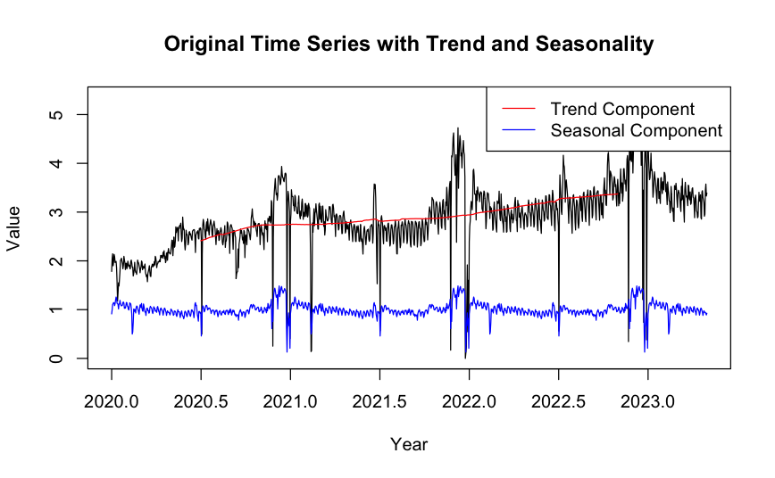

```r
lines(seasonal, col = "blue")
legend("topright", c("Trend Component","Seasonal Component"), col = c("red","blue"), lty=1)
```

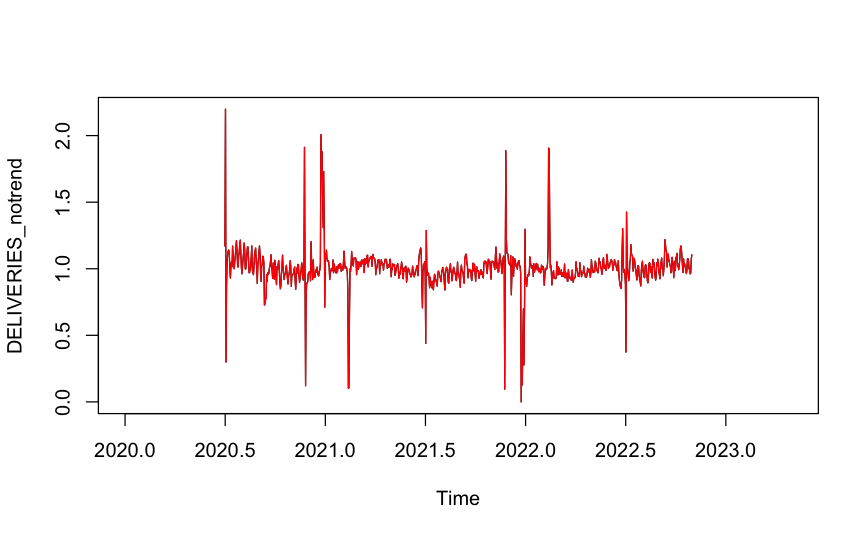

```r
DELIVERIES_notrend <- DELIVERIES / trend /seasonal
plot(DELIVERIES_notrend)
lines(random, col = "red")
```

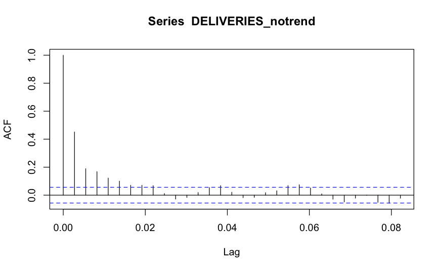

```r
acf(DELIVERIES_notrend,na.action = na.pass)
```

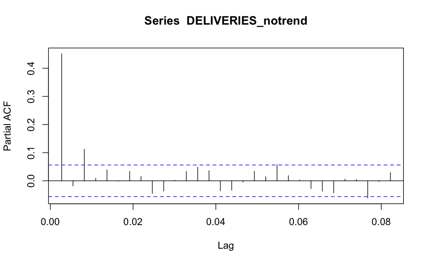

```r
pacf(DELIVERIES_notrend, na.action = na.pass)
```

```r
par(mfrow=c(2,2) , mar = c(3, 2, 3, 2))
acf(DELIVERIES,lag= 20, main = "Deliveries, ACF")
pacf(DELIVERIES,lag= 20, main ="Deliveries, PACF")
```

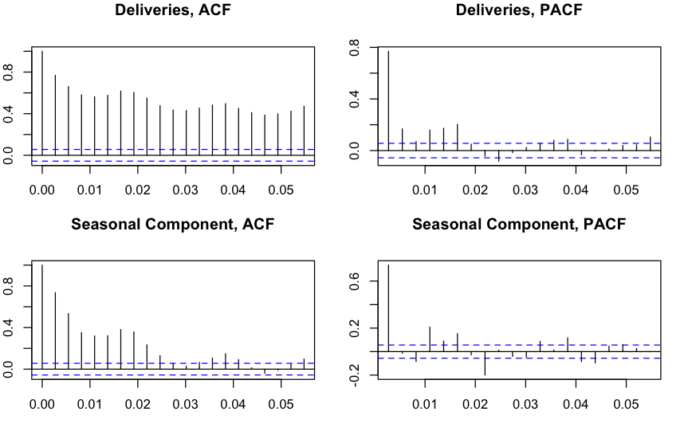

```r
acf(seasonal,lag= 20, main = "Seasonal Component, ACF")
pacf(seasonal,lag= 20, main ="Seasonal Component, PACF")
```

**Notes:** Looking at the ACF and PACF of the seasonal component in comparison to the original times series we see that the patterns are similar. The trend in the series is a deterministic trend (no unit root). Modeling the seasonal component will be similar to modelling the original series and vis-a-versa.

## 3. Models With No Seasonality

```r
# DATA SWITCH: Use all data for in sample evaluation
DATA <- DELIVERIES

# create a vector to store reference to all the models
model_names <- c()
model_aic <- c()
model_bic <- c()
model_cor <- c()
model_adjR2 <- c()
model_stationary <- c()
model_invertible <-c()
model_res_box_text <- c()
```

```r
store.function <- function(name = "None",this_model,stationary = TRUE,invertible = TRUE){
  model_names <<- append(model_names,name)
  model_aic <<- append(model_aic,AIC(this_model))
  model_bic <<- append(model_bic,BIC(this_model))

  this_cor <<- cor(fitted(this_model), DATA, use="pairwise.complete.obs")^2
  model_cor<<-append(model_cor,this_cor)
  num <- length(DATA)
  this_adjR2 <<- 1-(1-this_cor)*(num-1)/(num-2)
  model_adjR2<<-append(model_adjR2,this_adjR2)

  this_res_box <<- Box.test(this_model$residuals, type="Ljung-Box")
  model_res_box_text<<-append(model_res_box_text,this_res_box$p.value)
  model_stationary <<- append(model_stationary,stationary)
  model_invertible <<- append(model_invertible,invertible)
}
```

#### 3.1 Model 1: Auto ARIMA model

```r
auto_arima <- auto.arima(DATA)
auto_arima
```

```
Series: DATA
ARIMA(5,1,3)

Coefficients:
         ar1      ar2     ar3     ar4     ar5      ma1     ma2      ma3
      1.6864  -1.3690  0.3016  0.0839  0.0610  -2.1855  2.0846  -0.8774
s.e.  0.0340   0.0701  0.0737  0.0594  0.0312   0.0184  0.0497   0.0402

sigma^2 = 0.1556:  log likelihood = -591.01
AIC=1200.02   AICc=1200.17   BIC=1245.94
```

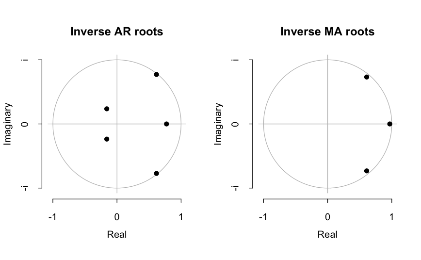

```r
plot(auto_arima)
```

```r
store.function("auto_arima",auto_arima,FALSE,TRUE)
```

#### 3.2 Pure AR Models: AR(1) Model, AR(2) Model, AR(6) Model

```r
# AR1
ar1 <- arima(DATA, order=c(1, 0, 0))
ar1
```

```
Call:
arima(x = DATA, order = c(1, 0, 0))

Coefficients:
         ar1  intercept
      0.7710     2.8843
s.e.  0.0183     0.0540

sigma^2 estimated as 0.1873:  log likelihood = -707.33,  aic = 1420.65
```

```r
ar2 <- arima(DATA, order=c(2, 0, 0))
ar2
```

```
Call:
arima(x = DATA, order = c(2, 0, 0))

Coefficients:
         ar1     ar2  intercept
      0.6406  0.1693     2.8831
s.e.  0.0282  0.0283     0.0641

sigma^2 estimated as 0.1819:  log likelihood = -689.65,  aic = 1387.3
```

```r
ar6 <- arima(DATA, order=c(6, 0, 0))
ar6
```

```
Call:
arima(x = DATA, order = c(6, 0, 0))

Coefficients:
         ar1     ar2      ar3     ar4     ar5     ar6  intercept
      0.5527  0.0980  -0.0382  0.0323  0.0552  0.2039     2.8760
s.e.  0.0281  0.0322   0.0323  0.0323  0.0322  0.0281     0.1183

sigma^2 estimated as 0.1636:  log likelihood = -625.63,  aic = 1267.26
```

```r
ar6_d1 <- arima(DATA, order=c(6, 1, 0))
ar6_d1
```

```
Call:
arima(x = DATA, order = c(6, 1, 0))

Coefficients:
          ar1      ar2      ar3      ar4      ar5      ar6
      -0.4408  -0.3343  -0.3636  -0.3172  -0.2566  -0.0705
s.e.   0.0286   0.0304   0.0305   0.0305   0.0304   0.0286

sigma^2 estimated as 0.1658:  log likelihood = -632.88,  aic = 1279.76
```

```r
par(mfrow=c(2,2) , mar = c(3, 2, 3, 2))
plot(ar1, main ="AR1: Inverse Roots")
plot(ar2, main ="AR2: Inverse Roots")
```

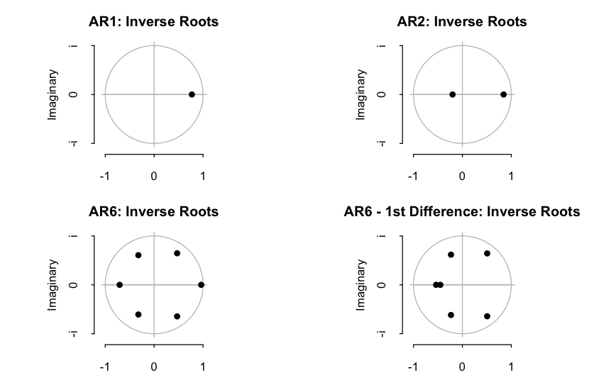

```r
plot(ar6, main ="AR6: Inverse Roots")
plot(ar6_d1, main ="AR6 - 1st Difference: Inverse Roots")
```

**Notes:** The AR6 model looks quite good with a very good AIC. However 1 root is very close to 1 making it not sufficiently stationary so decided to model with the first difference.

```r
store.function("ar1",ar1,TRUE,TRUE)
store.function("ar2",ar2,TRUE,TRUE)
store.function("ar6",ar6,FALSE,TRUE)
store.function("ar6_d1",ar6_d1,TRUE,TRUE)
```

#### 3.3 Pure MA Models: Models 7,8: MA(1) Model, MA(2) Model

```r
ma1 <- arima(DATA, order=c(0, 0, 1))
ma1
```

```
Call:
arima(x = DATA, order = c(0, 0, 1))

Coefficients:
         ma1  intercept
      0.5584     2.8854
s.e.  0.0178     0.0237

sigma^2 estimated as 0.2821:  log likelihood = -956.15,  aic = 1918.3
```

```r
ma2 <- arima(DATA, order=c(0, 0, 2))
ma2
```

```
Call:
arima(x = DATA, order = c(0, 0, 2))

Coefficients:
         ma1     ma2  intercept
      0.6705  0.3966     2.8853
s.e.  0.0276  0.0223     0.0282

sigma^2 estimated as 0.2272:  log likelihood = -824.74,  aic = 1657.47
```

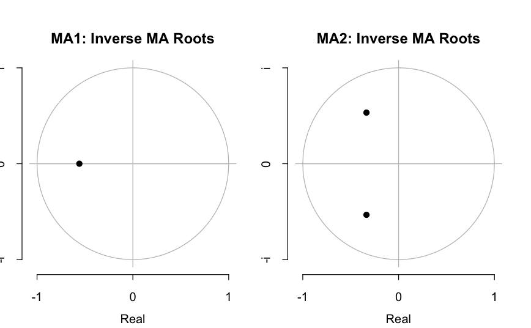

```r
par(mfrow=c(1,2) , mar = c(3, 2, 3, 2))
plot(ma1, main ="MA1: Inverse MA Roots")
plot(ma2, main ="MA2: Inverse MA Roots")
```

```r
store.function("ma1",ma1,TRUE,TRUE)
store.function("ma2",ma2,TRUE,TRUE)
```

**Notes:** The pure MA models have much higher aic we will still store the key values for future reference.

#### 3.4 ARMA Models:

```r
# ARMA(1,1)
ar1_ma1 <- arima(DATA, order=c(1, 0, 1))
ar1_ma1
```

```
Call:
arima(x = DATA, order = c(1, 0, 1))

Coefficients:
         ar1      ma1  intercept
      0.8968  -0.3418     2.8833
s.e.  0.0199   0.0542     0.0770

sigma^2 estimated as 0.1798:  log likelihood = -682.63,  aic = 1373.26
```

```r
# ARMA(1,2)
ar1_ma2 <- arima(DATA, order=c(1, 0, 2))
ar1_ma2
```

```
Call:
arima(x = DATA, order = c(1, 0, 2))

Coefficients:
         ar1      ma1      ma2  intercept
      0.9695  -0.4447  -0.2172     2.8811
s.e.  0.0096   0.0302   0.0286     0.1292

sigma^2 estimated as 0.1726:  log likelihood = -657.96,  aic = 1325.92
```

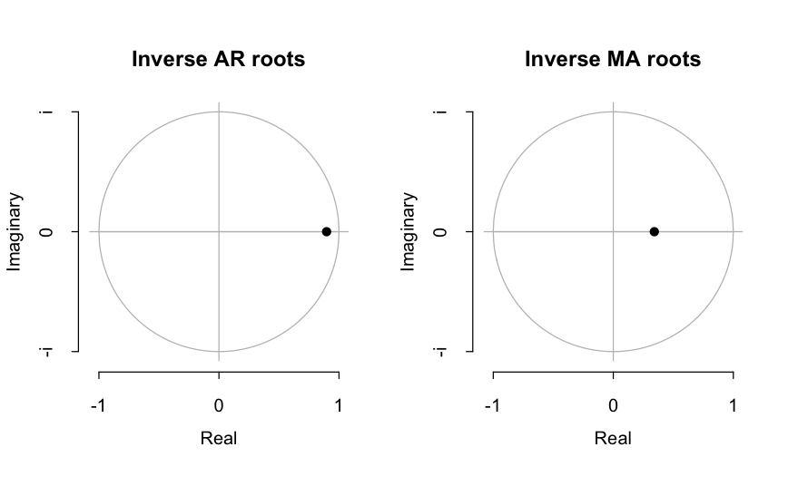

```r
plot(ar1_ma1)
```

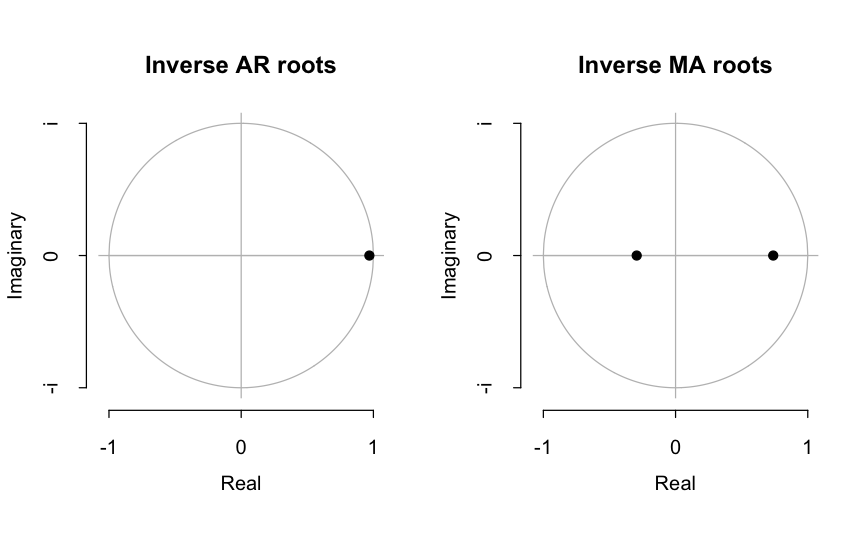

```r
store.function("ar1_ma1",ar1_ma1,TRUE,TRUE)
plot(ar1_ma2)
```

```r
store.function("ar1_ma2",ar1_ma2,TRUE,TRUE)
```

```r
# ARMA(2,0,2)
ar2_ma2 <- arima(DATA, order=c(2, 0, 2))
ar2_ma2
```

```
Call:
arima(x = DATA, order = c(2, 0, 2))

Coefficients:
         ar1      ar2      ma1     ma2  intercept
      1.5546  -0.5566  -0.9995  0.0537     2.8532
s.e.  0.0612   0.0603   0.0668  0.0539     0.2860

sigma^2 estimated as 0.1686:  log likelihood = -643.83,  aic = 1299.65
```

```r
# ARMA(2,1,2)
ar2_ma2_d1 <- arima(DATA, order=c(2, 1, 2))
ar2_ma2_d1
```

```
Call:
arima(x = DATA, order = c(2, 1, 2))

Coefficients:
          ar1     ar2      ma1      ma2
      -0.3187  0.4709  -0.1251  -0.7833
s.e.   0.1087  0.0530   0.1111   0.1029

sigma^2 estimated as 0.1681:  log likelihood = -641.35,  aic = 1292.71
```

```r
# ARMA(2,1)
ar2_ma1 <- arima(DATA, order=c(2, 0, 1))
ar2_ma1
```

```
Call:
arima(x = DATA, order = c(2, 0, 1))

Coefficients:
         ar1      ar2      ma1  intercept
      1.4989  -0.5017  -0.9326     2.8433
s.e.  0.0387   0.0374   0.0223     0.2598

sigma^2 estimated as 0.1687:  log likelihood = -644.31,  aic = 1298.62
```

```r
# ARMA(2,1,1)
ar2_ma1_d1 <- arima(DATA, order=c(2, 1, 1))
ar2_ma1_d1
```

```
Call:
arima(x = DATA, order = c(2, 1, 1))

Coefficients:
         ar1     ar2      ma1
      0.5064  0.0398  -0.9524
s.e.  0.0316  0.0308   0.0130

sigma^2 estimated as 0.1688:  log likelihood = -643.74,  aic = 1295.48
```

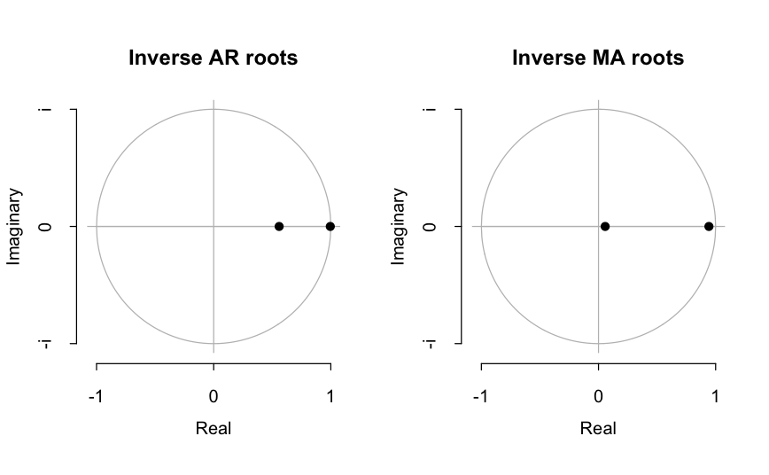

```r
plot(ar2_ma2)
```

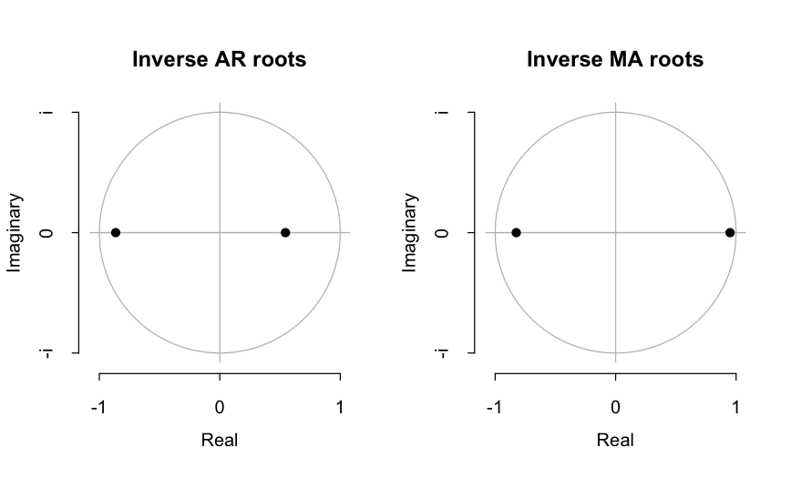

```r
store.function("ar2_ma2",ar2_ma2,FALSE,TRUE)
plot(ar2_ma2_d1)
```

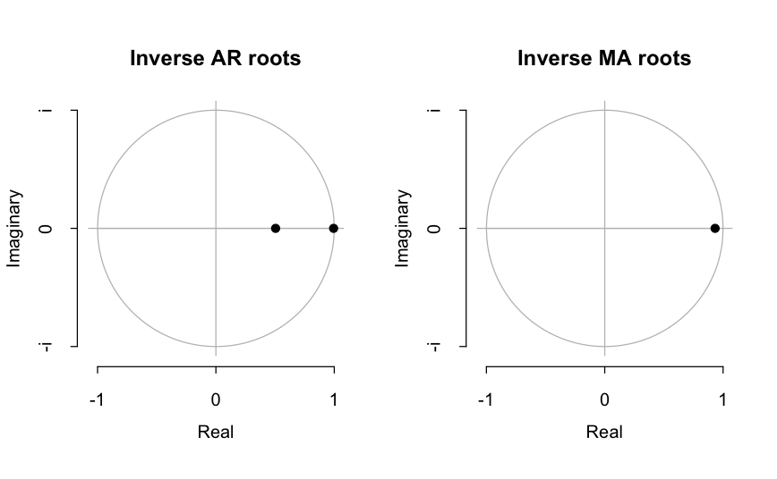

```r
store.function("ar2_ma2_d1",ar2_ma2_d1,TRUE,TRUE)
plot(ar2_ma1)
```

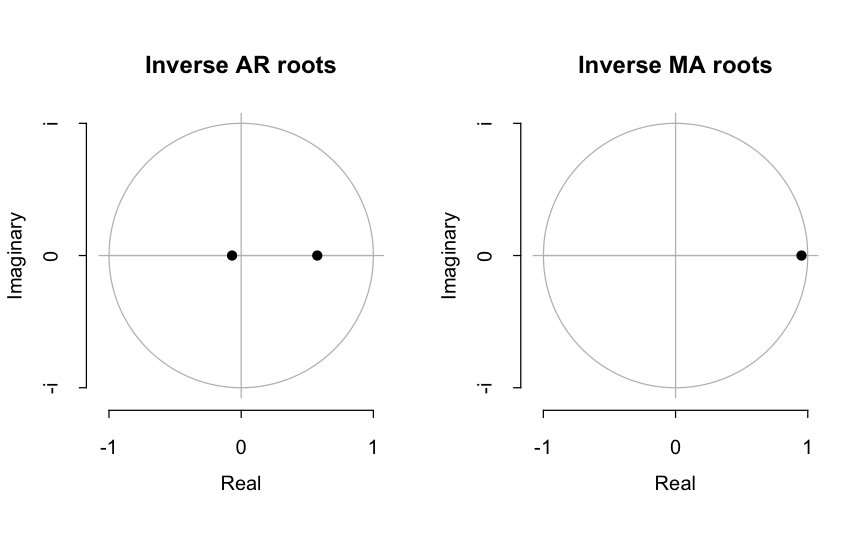

```r
store.function("ar2_ma1",ar2_ma1,FALSE,TRUE)
plot(ar2_ma1_d1)
```

```r
store.function("ar2_ma1_d1",ar2_ma1_d1,TRUE,TRUE)
```

```r
# ARMA(6,1)
ar6_ma1 <- arima(DATA, order=c(6, 0, 1))
ar6_ma1
```

```
Call:
arima(x = DATA, order = c(6, 0, 1))

Coefficients:
         ar1     ar2      ar3     ar4     ar5     ar6      ma1  intercept
      0.7016  0.0100  -0.0545  0.0393  0.0460  0.1795  -0.1562     2.8752
s.e.  0.1014  0.0666   0.0362  0.0350  0.0348  0.0346   0.1013     0.1228

sigma^2 estimated as 0.1633:  log likelihood = -624.53,  aic = 1267.05
```

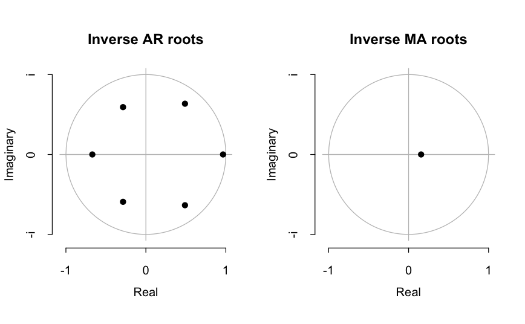

```r
plot(ar6_ma1)
```

```r
store.function("ar6_ma1",ar6_ma1,FALSE,TRUE)
# ARMA(6,1,1)
ar6_ma1_d1 <- arima(DATA, order=c(6, 1, 1))
ar6_ma1_d1
```

```
Call:
arima(x = DATA, order = c(6, 1, 1))

Coefficients:
          ar1      ar2      ar3      ar4      ar5      ar6     ma1
      -0.5618  -0.3859  -0.4018  -0.3585  -0.2926  -0.0987  0.1214
s.e.   0.2410   0.1060   0.0809   0.0868   0.0767   0.0594  0.2409

sigma^2 estimated as 0.1658:  log likelihood = -632.76,  aic = 1281.51
```

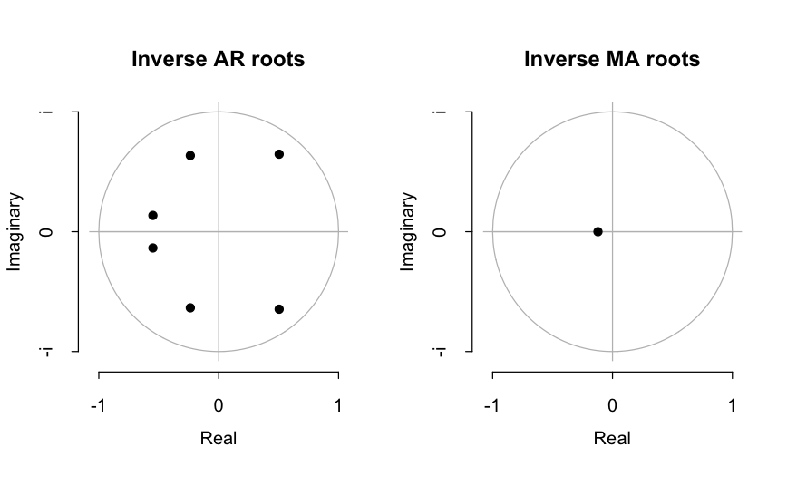

```r
plot(ar6_ma1_d1)
```

```r
store.function("ar6_ma1_d1",ar6_ma1_d1,TRUE,TRUE)

# ARMA(6,2)
ar6_ma2 <- arima(DATA, order=c(6, 0, 2))
ar6_ma2
```

```
Call:
arima(x = DATA, order = c(6, 0, 2))

Coefficients:
         ar1      ar2     ar3     ar4      ar5     ar6      ma1     ma2  intercept
      1.7253  -1.3882  0.3315  0.1936  -0.0533  0.1108  -1.1972  0.8917     2.8844
s.e.  0.0373   0.0774  0.0738  0.0713   0.0657  0.0348   0.0223  0.0443     0.0974

sigma^2 estimated as 0.1584:  log likelihood = -606.08,  aic = 1232.16
```

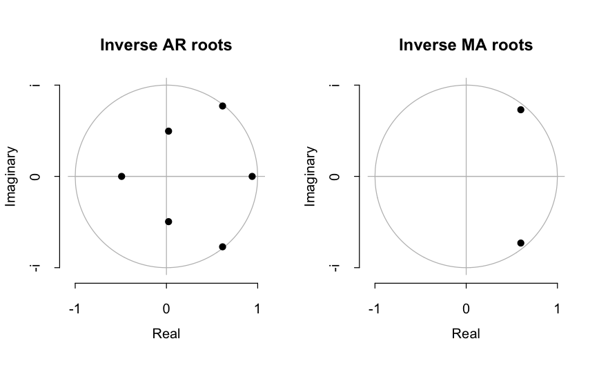

```r
plot(ar6_ma2)
```

```r
store.function("ar6_ma2",ar6_ma2,FALSE,TRUE)
# ARMA(6,1,2)
ar6_ma2_d1 <- arima(DATA, order=c(6, 1, 2))
ar6_ma2_d1
```

```
Call:
arima(x = DATA, order = c(6, 1, 2))

Coefficients:
         ar1      ar2      ar3      ar4      ar5      ar6      ma1    ma2
      0.7619  -0.7010  -0.3305  -0.1230  -0.0912  -0.1085  -1.2102  0.949
s.e.  0.0317   0.0384   0.0413   0.0411   0.0363   0.0316   0.0130  0.019

sigma^2 estimated as 0.1617:  log likelihood = -618.22,  aic = 1254.44
```

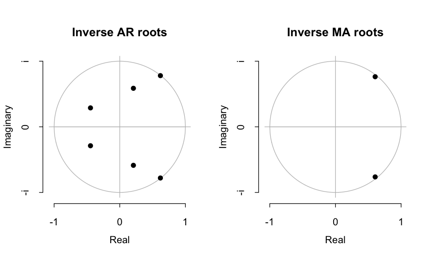

```r
plot(ar6_ma2_d1)
```

```r
store.function("ar6_ma2_d1",ar6_ma2_d1,FALSE,FALSE)

# ARMA(6,4)
ar6_ma4 <- arima(DATA, order=c(6, 0, 4))
ar6_ma4
```

```
Call:
arima(x = DATA, order = c(6, 0, 4))

Coefficients:
         ar1      ar2      ar3     ar4      ar5      ar6      ma1      ma2     ma3      ma4
      1.6866  -0.4460  -1.3581  1.5107  -0.2720  -0.1257  -1.1799  -0.0140  1.1852  -0.8975
s.e.  0.0314   0.0531   0.0612  0.0607   0.0574   0.0357   0.0157   0.0148  0.0290   0.0357
      intercept
         2.8726
s.e.     0.2139

sigma^2 estimated as 0.1553:  log likelihood = -596.14,  aic = 1216.28
```

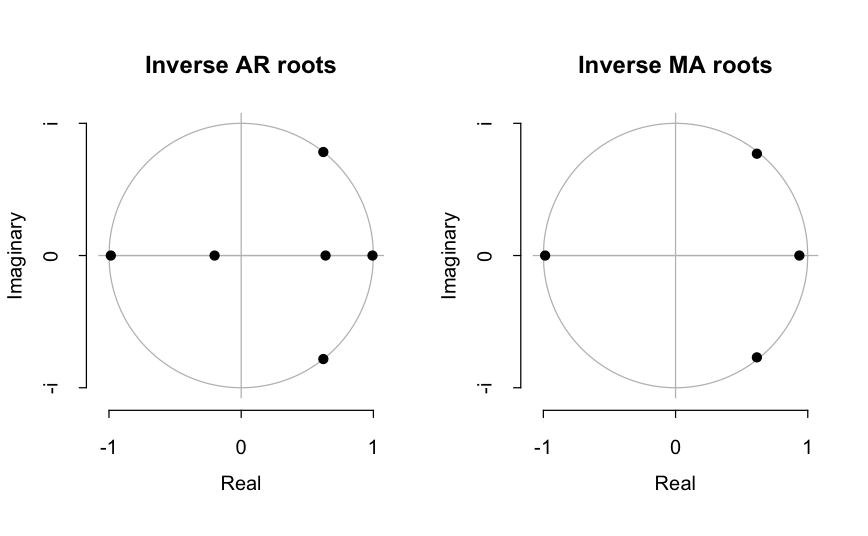

```r
plot(ar6_ma4)
```

```r
store.function("ar6_ma4",ar6_ma4,FALSE,FALSE)
# ARMA(6,1,4)
ar6_ma4_d1 <- arima(DATA, order=c(6, 1, 4))
ar6_ma4_d1
```

```
Call:
arima(x = DATA, order = c(6, 1, 4))

Coefficients:
         ar1      ar2      ar3     ar4     ar5     ar6      ma1     ma2     ma3      ma4
      0.9103  -0.0763  -0.7650  0.3702  0.0573  0.0887  -1.4085  0.3977  0.7357  -0.6871
s.e.  0.2269   0.3909   0.3079  0.0593  0.0667  0.0314   0.2264  0.5022  0.4746   0.1974

sigma^2 estimated as 0.154:  log likelihood = -588.74,  aic = 1199.47
```

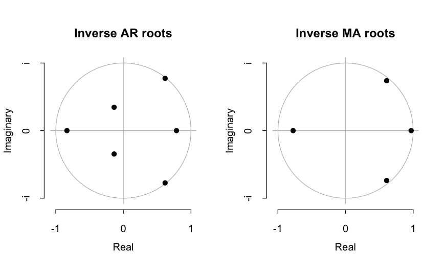

```r
plot(ar6_ma4_d1)
```

```r
store.function("ar6_ma4_d1",ar6_ma4_d1,FALSE,FALSE)

# ARMA(6,6)
ar6_ma6 <- arima(DATA, order=c(6, 0, 6))
ar6_ma6
```

```
Call:
arima(x = DATA, order = c(6, 0, 6))

Coefficients:
         ar1     ar2      ar3     ar4     ar5      ar6      ma1      ma2     ma3      ma4
      1.0792  0.8903  -2.0527  0.6991  1.1082  -0.7269  -0.5868  -1.0468  1.4951  -0.1038
s.e.  0.0264  0.0429   0.0651  0.0469  0.0484   0.0442   0.0430   0.0336  0.0620   0.0575
          ma5     ma6  intercept
      -0.9823  0.3022     2.8265
s.e.   0.0387  0.0460     0.2623

sigma^2 estimated as 0.1534:  log likelihood = -588.15,  aic = 1204.3
```

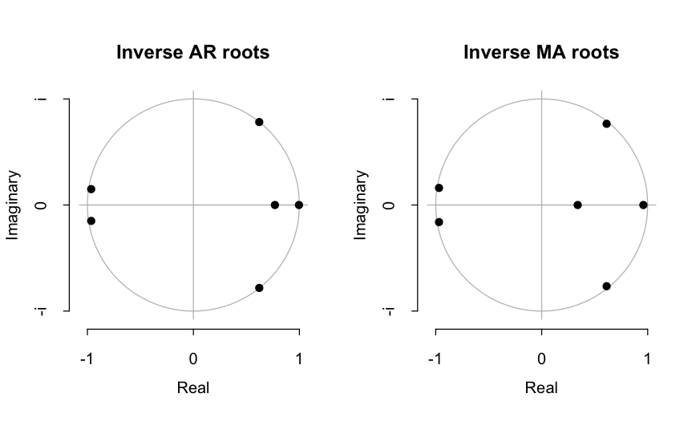

```r
plot(ar6_ma6)
```

```r
store.function("ar6_ma6",ar6_ma6,FALSE,FALSE)
# ARMA(6,1,6)
ar6_ma6_d1 <- arima(DATA, order=c(6, 1, 6))
ar6_ma6_d1
```

```
Call:
arima(x = DATA, order = c(6, 1, 6))

Coefficients:
         ar1     ar2      ar3      ar4     ar5      ar6      ma1      ma2     ma3     ma4
      0.6949  0.2083  -0.5500  -0.3542  0.7363  -0.0819  -1.1962  -0.0026  0.6521  0.1645
s.e.  0.1663  0.5903   0.9284   0.7290  0.1847   0.1237   0.1619   0.5966  1.1295  1.0455
          ma5     ma6
      -1.0036  0.4156
s.e.   0.4435  0.1146

sigma^2 estimated as 0.1536:  log likelihood = -587.26,  aic = 1200.52
```

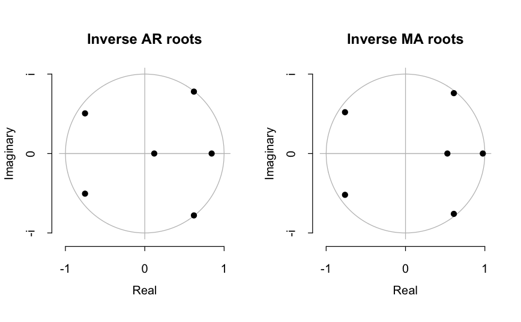

```r
plot(ar6_ma6_d1)
```

```r
store.function("ar6_ma6_d1",ar6_ma6_d1,FALSE,FALSE)
```

**Notes on ARMA model:** As we use more complex processes i.e. higher order of AR and MA it becomes harder to find model where the roots are stationary and invertible. Modeling the ARMA(6,q) process we see that only ARMA(6,1,1) is having all roots that are within the circle.

## 4. Models with Seasonality

#### 4.0 ACF and PACF of with diff(7)

```r
diff_weekly <- diff(DATA,7)
ts.plot(diff_weekly)
ur.df(diff_weekly,type="drift",lags=0)
```

```
###############################################################
# Augmented Dickey-Fuller Test Unit Root / Cointegration Test #
###############################################################

The value of the test statistic is: -20.9992 220.4838
```

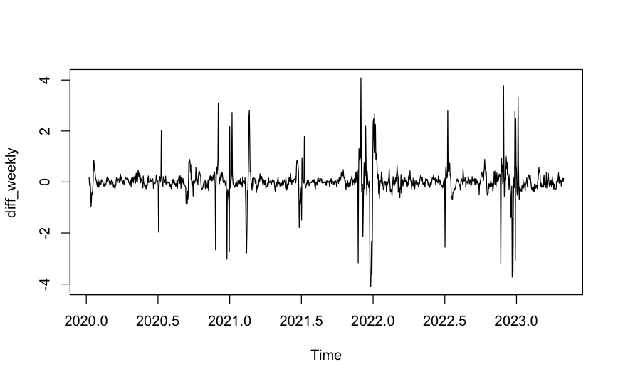

```r
par(mfrow=c(1,2), mar = c(3, 2, 3, 2))
```

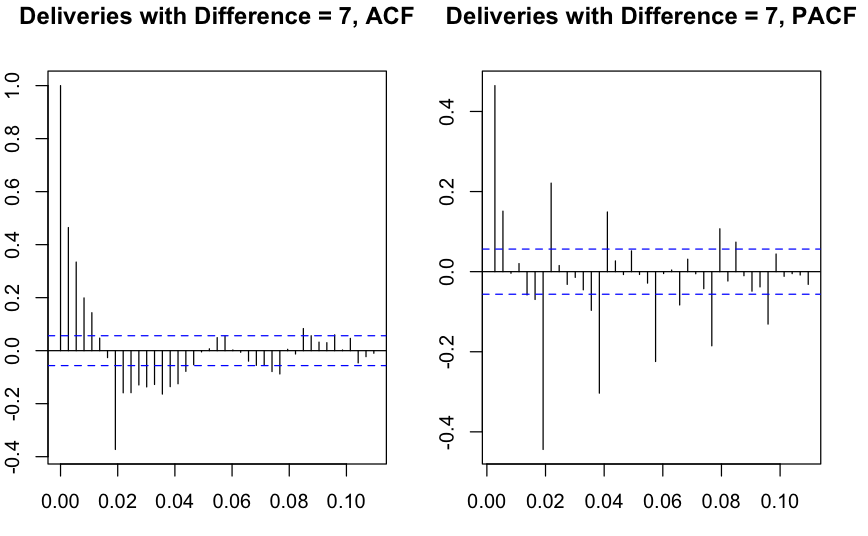

```r
acf(diff_weekly, lag = 40, na.action = na.pass, main = "Deliveries with Difference = 7, ACF")
pacf(diff_weekly, lag = 40,  na.action = na.pass, main = "Deliveries with Difference = 7, PACF")
```

**Choice of Tentative Seasonal Arima Models** We plan to consider seasonal Arima models of the form (p,d,q)(P,D,Q)[7] as out data has weekly cycles. To identify the order for the seasonal model we look at the ACF and PACF of the Diff(7) of the original series. Looking at the ACF we see gradually falling spikes -> indicates AR behavior. On the PACF there are spikes at lag = 1,2 and 7 indicating AR2 or AR7 models. The PACF also has a rapidly declining autocorrelation. Looking at the ACF we see there are spike at Lag = 1,2,3,4 and 7 indicating MA1 , MA2, MA3, MA4, MA7 . Note in our analysis we do not consider the spikes after the 7th lag as these are in the cyclical pattern. We will try the following tentative models. We try to model simpler models first before going with models with higher complexity 1. sarima_ar2_ma1 = (2,0,0)(0,0,1)[7] 2. sarima_ar2_ma4 = (2,0,0)(0,0,4)[7] 3. sarima_ar7_ma1 = (7,0,0)(0,0,1)[7] 4. sarima_ar7_ma4 = (7,0,0)(0,0,4)[7]

```r
sarima_ar2_ma1 = arima(DATA, order = c(2,0,0), seasonal = list(order = c(0,0,1), period = 7))
sarima_ar2_ma1
```

```
Call:
arima(x = DATA, order = c(2, 0, 0), seasonal = list(order = c(0, 0, 1), period = 7))

Coefficients:
         ar1     ar2    sma1  intercept
      0.5955  0.1858  0.1544     2.8830
s.e.  0.0293  0.0283  0.0269     0.0634

sigma^2 estimated as 0.177:  log likelihood = -673.08,  aic = 1356.16
```

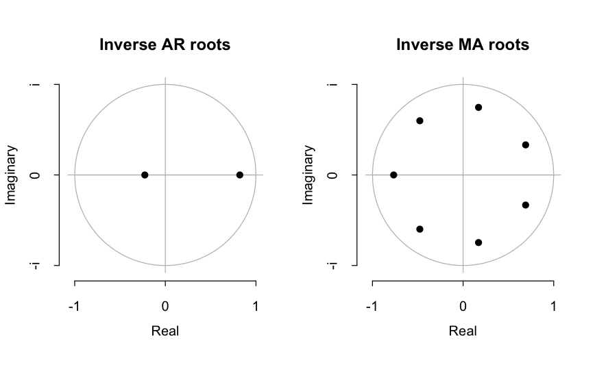

```r
plot(sarima_ar2_ma1)
```

```r
store.function("sarima_ar2_ma1",sarima_ar2_ma1,TRUE,TRUE)
```

```r
sarima_ar2_ma4 = arima(DATA, order = c(2,0,0), seasonal = list(order = c(0,0,4), period = 7))
sarima_ar2_ma4
```

```
Call:
arima(x = DATA, order = c(2, 0, 0), seasonal = list(order = c(0, 0, 4), period = 7))

Coefficients:
         ar1     ar2    sma1    sma2    sma3    sma4  intercept
      0.5607  0.1866  0.1556  0.1342  0.1533  0.0413     2.8817
s.e.  0.0295  0.0282  0.0303  0.0296  0.0277  0.0268     0.0687

sigma^2 estimated as 0.1688:  log likelihood = -644.6,  aic = 1305.2
```

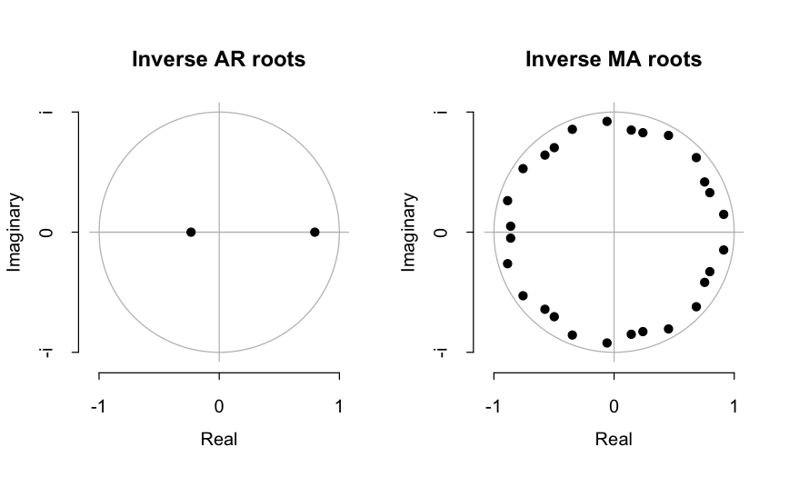

```r
plot(sarima_ar2_ma4)
```

```r
store.function("sarima_ar2_ma4",sarima_ar2_ma4,TRUE,TRUE)
```

```r
sarima_ar7_ma1 = arima(DATA, order = c(7,0,0), seasonal = list(order = c(0,0,1), period = 7))
sarima_ar7_ma1
```

```
Call:
arima(x = DATA, order = c(7, 0, 0), seasonal = list(order = c(0, 0, 1), period = 7))

Coefficients:
         ar1     ar2      ar3     ar4     ar5     ar6     ar7    sma1  intercept
      0.5422  0.0963  -0.0394  0.0347  0.0500  0.1752  0.0485  0.0066     2.8751
s.e.  0.0287  0.0331   0.0324  0.0323  0.0323  0.0323  0.0404  0.0422     0.1233

sigma^2 estimated as 0.1632:  log likelihood = -623.9,  aic = 1267.81
```

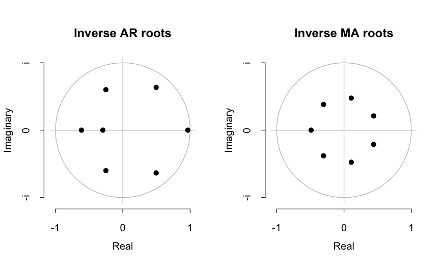

```r
plot(sarima_ar7_ma1)
```

```r
store.function("sarima_ar7_ma1",sarima_ar7_ma1,TRUE,TRUE)
```

```r
sarima_ar7_ma4 = arima(DATA, order = c(7,0,0), seasonal = list(order = c(0,0,4), period = 7))
sarima_ar7_ma4
```

```
Call:
arima(x = DATA, order = c(7, 0, 0), seasonal = list(order = c(0, 0, 4), period = 7))

Coefficients:
         ar1     ar2      ar3     ar4     ar5     ar6      ar7    sma1    sma2    sma3
      0.5330  0.1192  -0.0327  0.0450  0.0553  0.1641  -0.0181  0.0628  0.0605  0.1325
s.e.  0.0288  0.0330   0.0327  0.0324  0.0323  0.0326   0.0414  0.0457  0.0319  0.0289
        sma4  intercept
      0.0248     2.8783
s.e.  0.0276     0.1076

sigma^2 estimated as 0.1595:  log likelihood = -610.38,  aic = 1246.77
```

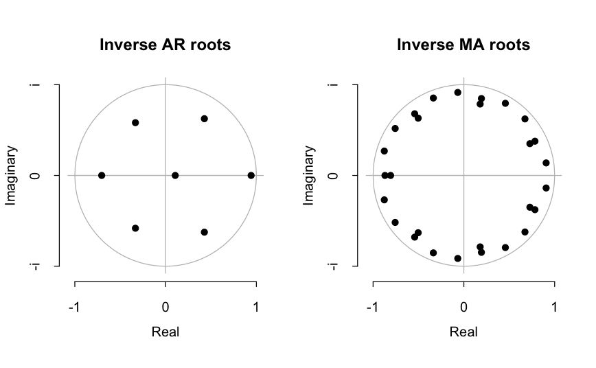

```r
plot(sarima_ar7_ma4)
```

```r
store.function("sarima_ar7_ma4",sarima_ar7_ma4,TRUE,TRUE)
#
# fcast1<-numeric(prediction_size)
# ferror1<-numeric(prediction_size)
# loss1<-numeric(prediction_size)
#
# for (i in  1: prediction_size) {
# refit_sarima_ar7_ma4 <- Arima(DELIVERIES[1:estimation_size + i], model=sarima_ar7_ma4)
# fcast1[i]<-forecast(refit_sarima_ar7_ma4, h=1)$mean
# ferror1[i] <- ps[i] - fcast1[i]
# loss1[i] <- ferror1[i]^2
# }
#
# mpetest1 <- lm(ferror1 ~ 1)
# summary(mpetest1)
#
# IETest1 <- lm(ferror1 ~ fcast1)
# summary(IETest1)
```